# Assignment3

TemmirlanZholaman

2023-02-18

Use boxplots to remove outliers in the data

```
##      carat            cut               color             clarity
##  Min.   :0.2000   Length:53940       Length:53940       Length:53940
##  1st Qu.:0.4000   Class :character   Class :character   Class :character
##  Median :0.7000   Mode  :character   Mode  :character   Mode  :character
##  Mean   :0.7979
##  3rd Qu.:1.0400
##  Max.   :5.0100
##      depth           table           price             x
##  Min.   :43.00   Min.   :43.00   Min.   :  326   Min.   : 0.000
##  1st Qu.:61.00   1st Qu.:56.00   1st Qu.:  950   1st Qu.: 4.710
##  Median :61.80   Median :57.00   Median : 2401   Median : 5.700
##  Mean   :61.75   Mean   :57.46   Mean   : 3933   Mean   : 5.731
##  3rd Qu.:62.50   3rd Qu.:59.00   3rd Qu.: 5324   3rd Qu.: 6.540
##  Max.   :79.00   Max.   :95.00   Max.   :18823   Max.   :10.740
##        y                z
##  Min.   : 0.000   Min.   : 0.000
##  1st Qu.: 4.720   1st Qu.: 2.910
##  Median : 5.710   Median : 3.530
##  Mean   : 5.735   Mean   : 3.539
##  3rd Qu.: 6.540   3rd Qu.: 4.040
##  Max.   :58.900   Max.   :31.800
```

```r
data<-raw_data
data$size <- ifelse(data$carat < 0.3 , "small",
                    ifelse(data$carat> 1, "large", "medium"))
data_2 <- subset(data, select=-c(carat))
data<- subset(data, select=-c(size))
head(data, 5)
```

```
## # A tibble: 5 x 10
##   carat cut     color clarity depth table price     x     y     z
##   <dbl> <chr>   <chr> <chr>   <dbl> <dbl> <dbl> <dbl> <dbl> <dbl>
## 1  0.23 Ideal   E     SI2      61.5    55   326  3.95  3.98  2.43
## 2  0.21 Premium E     SI1      59.8    61   326  3.89  3.84  2.31
## 3  0.23 Good    E     VS1      56.9    65   327  4.05  4.07  2.31
## 4  0.29 Premium I     VS2      62.4    58   334  4.2   4.23  2.63
## 5  0.31 Good    J     SI2      63.3    58   335  4.34  4.35  2.75
```

So the model of the experiment will contain regression analysis with including carat as a categorical feature (size = “small|medium”large), or as a continuous feature. Let’s start with EDA.

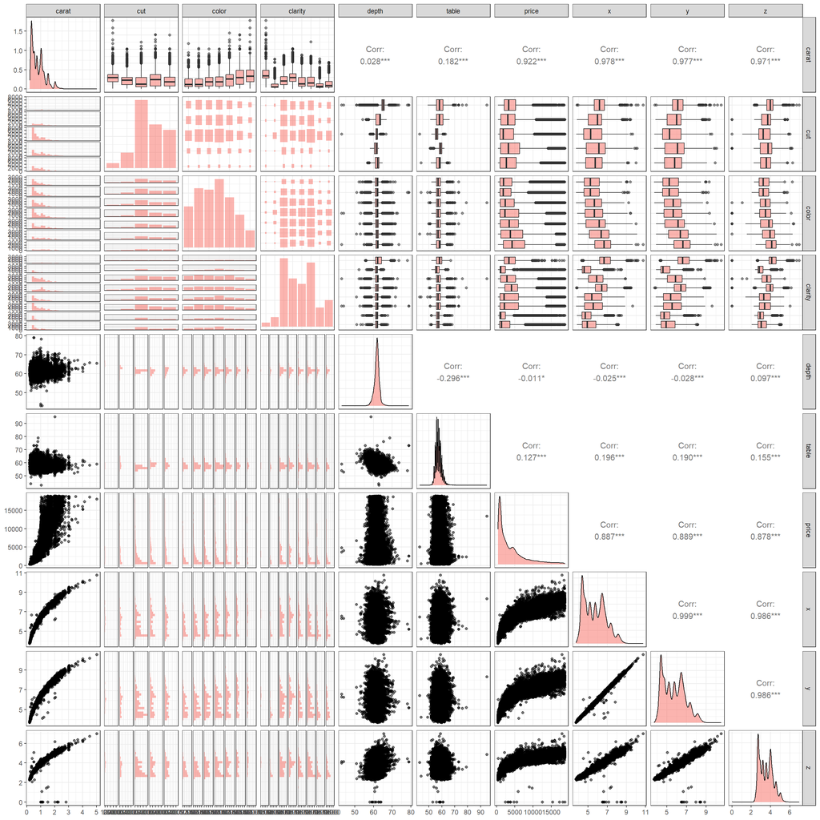

From distribution of data I would take notes on few things: *Distribution of carat in not normal, transformation would be great* Same problem with price, need to transform it *x,y,z coordinates clearly have some outliers. May work on it further* some of the features are highly correlated to price, such as x, y, z. Carat is has some kind of exponential/quadratical dependency, and this should be taken into account.

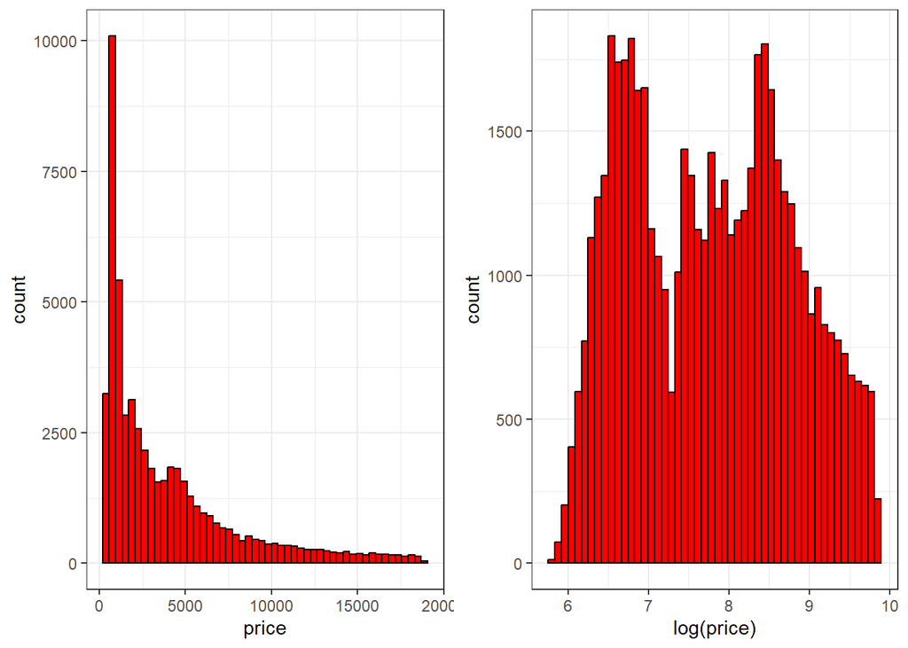

```r
g1 <- data %>%
  ggplot(aes(x=price)) +
  geom_histogram(fill='red', col='black', bins=50)

g2 <- data %>%
  ggplot(aes(x=log(price))) +
  geom_histogram(fill='red', col='black', bins=50)

grid.arrange(g1, g2, nrow=1)
```

$\frac{\max y}{\min y}=$ 57.7392638 $>10$, => Box-Cox transformation:

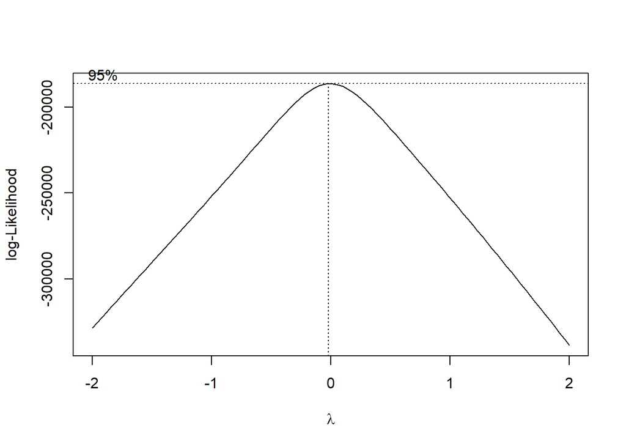

I will be using lambda = 0 for price transformation

```r
data$logprice <- log(data$price)
data$price <- NULL
head(data)
```

```
## # A tibble: 6 x 10
##   carat cut       color clarity depth table     x     y     z logprice
##   <dbl> <chr>     <chr> <chr>   <dbl> <dbl> <dbl> <dbl> <dbl>    <dbl>
## 1  0.23 Ideal     E     SI2      61.5    55  3.95  3.98  2.43     5.79
## 2  0.21 Premium   E     SI1      59.8    61  3.89  3.84  2.31     5.79
## 3  0.23 Good      E     VS1      56.9    65  4.05  4.07  2.31     5.79
## 4  0.29 Premium   I     VS2      62.4    58  4.2   4.23  2.63     5.81
## 5  0.31 Good      J     SI2      63.3    58  4.34  4.35  2.75     5.81
## 6  0.24 Very Good J     VVS2     62.8    57  3.94  3.96  2.48     5.82
```

Lets check other features, such as carat

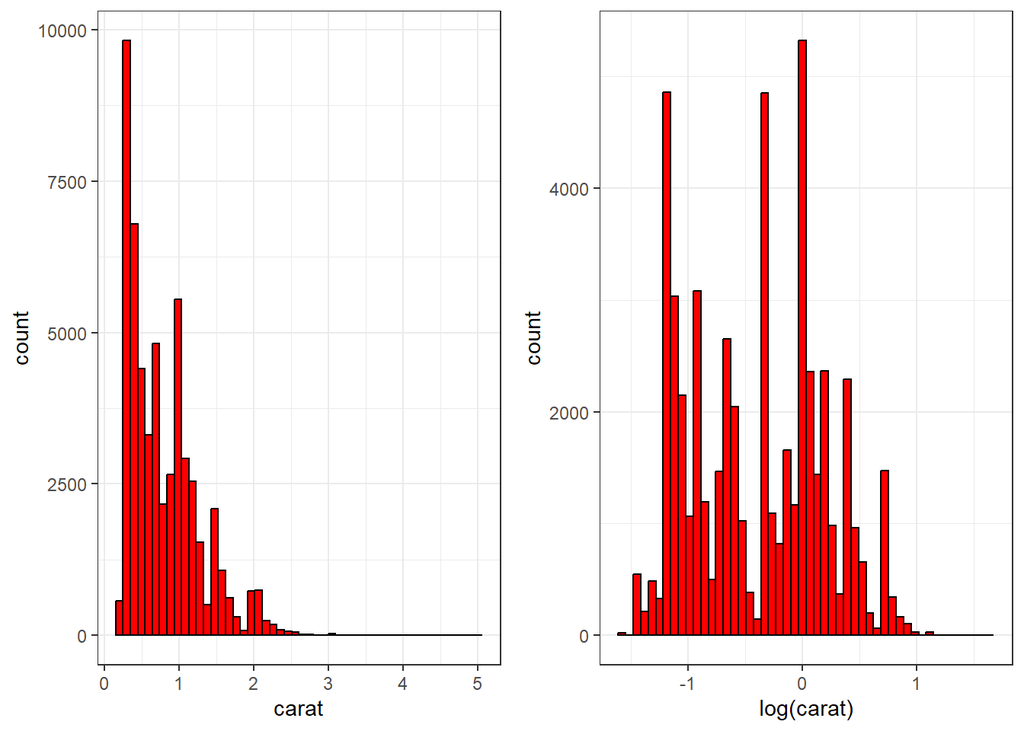

```r
g1 <- data %>%
  ggplot(aes(x=carat)) +
  geom_histogram(fill='red', col='black', bins=50)

g2 <- data %>%
  ggplot(aes(x=log(carat))) +
  geom_histogram(fill='red', col='black', bins=50)

grid.arrange(g1, g2, nrow=1)
```

$\frac{\max y}{\min y}=$ 25.05 $>10$, => Box-Cox transformation for carat:

I would use box-cox transformation with a direct lambda value

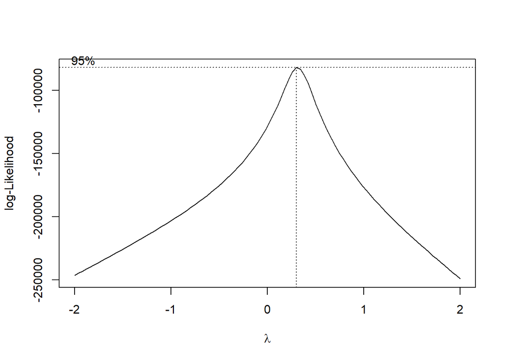

```
## [1] 0.3030303
```

### Model 1

Linear model with all the features.

```
##
## Call:
## lm(formula = logprice ~ ., data = data)
##
## Residuals:
##      Min       1Q   Median       3Q      Max
## -1.70152 -0.09773  0.01080  0.10200  1.87199
##
## Coefficients:
##                Estimate Std. Error  t value Pr(>|t|)
## (Intercept)  11.5512479  0.1762837   65.526  < 2e-16 ***
## cutGood       0.0758123  0.0047622   15.920  < 2e-16 ***
## cutIdeal      0.1500350  0.0047159   31.815  < 2e-16 ***
## cutPremium    0.1183200  0.0045080   26.247  < 2e-16 ***
## cutVery Good  0.1041142  0.0046078   22.595  < 2e-16 ***
## colorE       -0.0561546  0.0024957  -22.500  < 2e-16 ***
## colorF       -0.0896169  0.0025235  -35.513  < 2e-16 ***
## colorG       -0.1617263  0.0024713  -65.443  < 2e-16 ***
## colorH       -0.2696757  0.0026256 -102.710  < 2e-16 ***
## colorI       -0.4050753  0.0029437 -137.610  < 2e-16 ***
## colorJ       -0.5544946  0.0036314 -152.693  < 2e-16 ***
## clarityIF     1.1208790  0.0071368  157.056  < 2e-16 ***
## claritySI1    0.6462071  0.0060825  106.240  < 2e-16 ***
## claritySI2    0.4642143  0.0061128   75.942  < 2e-16 ***
## clarityVS1    0.8544302  0.0062171  137.432  < 2e-16 ***
## clarityVS2    0.7828874  0.0061184  127.956  < 2e-16 ***
## clarityVVS1   1.0273313  0.0065924  155.836  < 2e-16 ***
## clarityVVS2   0.9676052  0.0064081  150.998  < 2e-16 ***
## depth        -0.0191701  0.0010730  -17.866  < 2e-16 ***
## table        -0.0025678  0.0004274   -6.008 1.89e-09 ***
## x            -0.2180230  0.0165915  -13.141  < 2e-16 ***
## y            -0.1636580  0.0151136  -10.829  < 2e-16 ***
## z             0.0004696  0.0090478    0.052    0.959
## logcarat      2.8756139  0.0369232   77.881  < 2e-16 ***
## ---
## Signif. codes:  0 '***' 0.001 '**' 0.01 '*' 0.05 '.' 0.1 ' ' 1
##
## Residual standard error: 0.1576 on 53905 degrees of freedom
## Multiple R-squared:  0.9759, Adjusted R-squared:  0.9759
## F-statistic: 9.482e+04 on 23 and 53905 DF,  p-value: < 2.2e-16
```

Residuals visual inspection:

```
## # A tibble: 53,929 x 10
##    cut       color clarity depth table     x     y     z logprice logcarat
##    <chr>     <chr> <chr>   <dbl> <dbl> <dbl> <dbl> <dbl>    <dbl>    <dbl>
##  1 Ideal     E     SI2      61.5    55  3.95  3.98  2.43     5.79   -1.19
##  2 Premium   E     SI1      59.8    61  3.89  3.84  2.31     5.79   -1.24
##  3 Good      E     VS1      56.9    65  4.05  4.07  2.31     5.79   -1.19
##  4 Premium   I     VS2      62.4    58  4.2   4.23  2.63     5.81   -1.03
##  5 Good      J     SI2      63.3    58  4.34  4.35  2.75     5.81   -0.986
##  6 Very Good J     VVS2     62.8    57  3.94  3.96  2.48     5.82   -1.16
##  7 Very Good I     VVS1     62.3    57  3.95  3.98  2.47     5.82   -1.16
##  8 Very Good H     SI1      61.9    55  4.07  4.11  2.53     5.82   -1.11
##  9 Fair      E     VS2      65.1    61  3.87  3.78  2.49     5.82   -1.21
## 10 Very Good H     VS1      59.4    61  4     4.05  2.39     5.82   -1.19
## # ... with 53,919 more rows
```

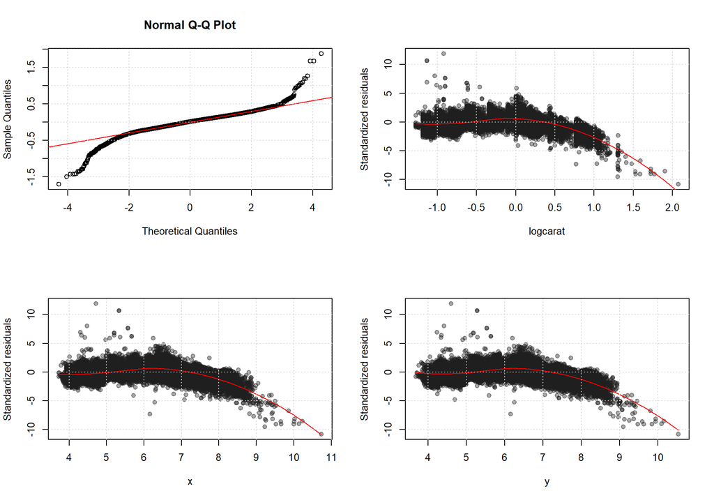

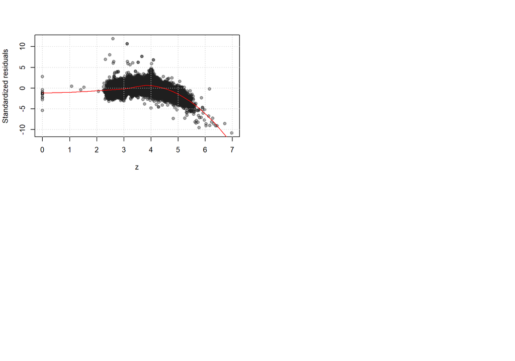

Things I have noticed: * there are outliers in x, y, z * there might be a small quadratic dependence in x, y, z, and carat. * q-q residuals plot shows some normality, but again, outliers. Lets try model with quadratic features ### Model 2 Adding to the model the square of x, y, z, & carat.

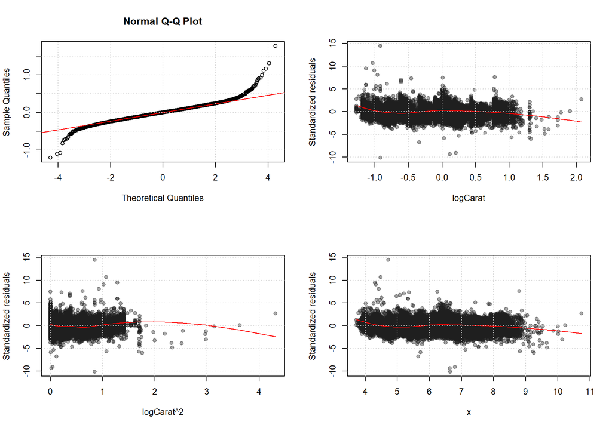

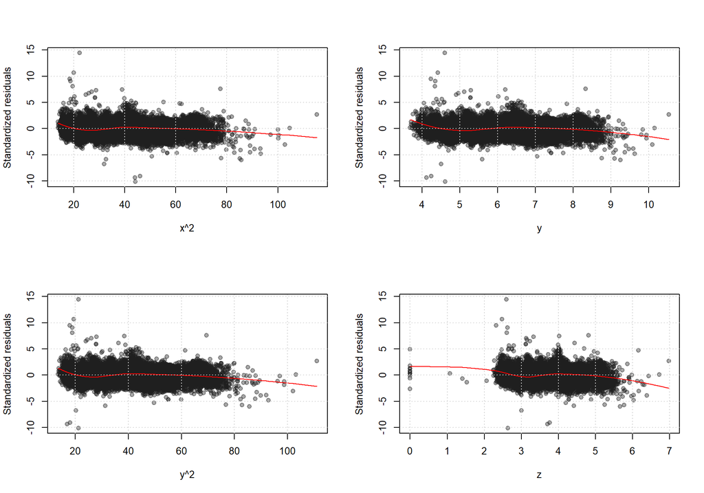

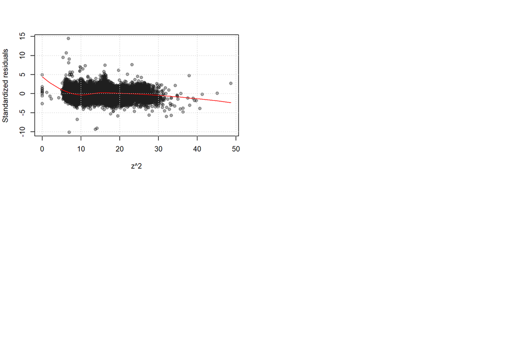

Follow-up tests for the residuals:

| Test | p-value |
| --- | --- |
| Shapiro-Wilk for first 5000 samples | 2.2190063^{-22} |
| Breusch-Pagan | 0 |
| Anderson-Darling test for full sample size | 3.7^{-24} |

They are not normal and heteroscedastic, so we’ll need to use White’s correction as well as adjustment for multiplicity when estimating the significance of the predictors:

```
##
## Call:
## lm(formula = logprice ~ . + I(x^2) + I(y^2) + I(z^2) + I(logcarat^2),
##     data = data)
##
## Residuals:
##      Min       1Q   Median       3Q      Max
## -1.20571 -0.07843  0.00097  0.07690  1.77439
##
## Coefficients:
##                  Estimate  Std. Error     t value    Pr(>|t|) Adjusted p-value
## (Intercept)     1.801e+00   2.767e-01   6.511e+00   7.519e-11              NaN
## cutGood         7.494e-02   3.741e-03   2.003e+01   5.956e-89            0.000
## cutIdeal        1.500e-01   3.694e-03   4.062e+01   0.000e+00            0.000
## cutPremium      1.256e-01   3.532e-03   3.555e+01  1.215e-273            0.000
## cutVery Good    1.073e-01   3.614e-03   2.970e+01  2.504e-192            0.000
## colorE         -5.472e-02   1.947e-03  -2.810e+01  1.658e-172            0.000
## colorF         -9.407e-02   1.969e-03  -4.776e+01   0.000e+00            0.000
## colorG         -1.605e-01   1.928e-03  -8.322e+01   0.000e+00            0.000
## colorH         -2.519e-01   2.051e-03  -1.228e+02   0.000e+00            0.000
## colorI         -3.737e-01   2.304e-03  -1.622e+02   0.000e+00            0.000
## colorJ         -5.160e-01   2.845e-03  -1.814e+02   0.000e+00            0.000
## clarityIF       1.102e+00   5.574e-03   1.976e+02   0.000e+00            0.000
## claritySI1      5.793e-01   4.768e-03   1.215e+02   0.000e+00            0.000
## claritySI2      4.157e-01   4.784e-03   8.688e+01   0.000e+00            0.000
## clarityVS1      7.979e-01   4.867e-03   1.639e+02   0.000e+00            0.000
## clarityVS2      7.265e-01   4.791e-03   1.516e+02   0.000e+00            0.000
## clarityVVS1     1.005e+00   5.150e-03   1.951e+02   0.000e+00            0.000
## clarityVVS2     9.325e-01   5.009e-03   1.861e+02   0.000e+00            0.000
## depth           1.706e-02   1.056e-03   1.615e+01   1.517e-58            0.000
## table           8.467e-04   3.360e-04   2.520e+00   1.174e-02            0.708
## x               5.121e+00   6.658e-02   7.692e+01   0.000e+00            0.000
## y              -3.971e+00   6.118e-02  -6.491e+01   0.000e+00            0.000
## z               2.816e-01   2.666e-02   1.056e+01   4.671e-26            0.000
## logcarat        1.457e+00   3.311e-02   4.399e+01   0.000e+00            0.000
## I(x^2)         -3.978e-01   5.185e-03  -7.671e+01   0.000e+00            0.000
## I(y^2)          3.328e-01   4.846e-03   6.866e+01   0.000e+00            0.000
## I(z^2)         -5.306e-02   5.097e-03  -1.041e+01   2.349e-25            0.001
## I(logcarat^2)   8.795e-02   2.372e-02   3.708e+00   2.091e-04            0.884
##
## Residual standard error: 0.123 on 53901 degrees of freedom
## Multiple R-squared:  0.9853, Adjusted R-squared:  0.9853
## F-statistic: 1.34e+05 on 27 and 53901 DF,  p-value: < 2.2e-16
```

Lets remove table and logcarat^2. ### Model3

```r
m3 <- lm(logprice ~ cut + color + clarity + depth + x + y + z + logcarat + I(x^2)+ I(y^2)+ I(z^2),
         data=data)
s3 <- summary(m3)
```

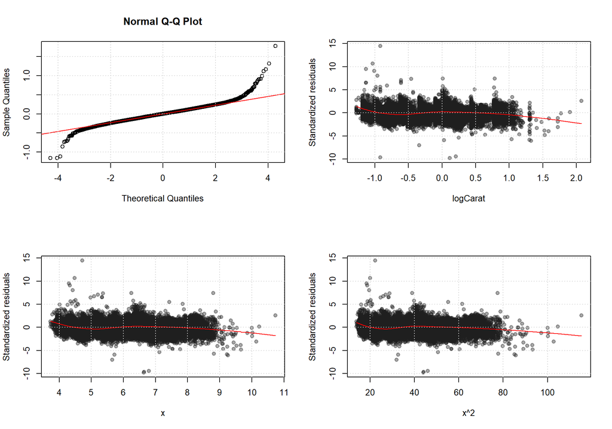

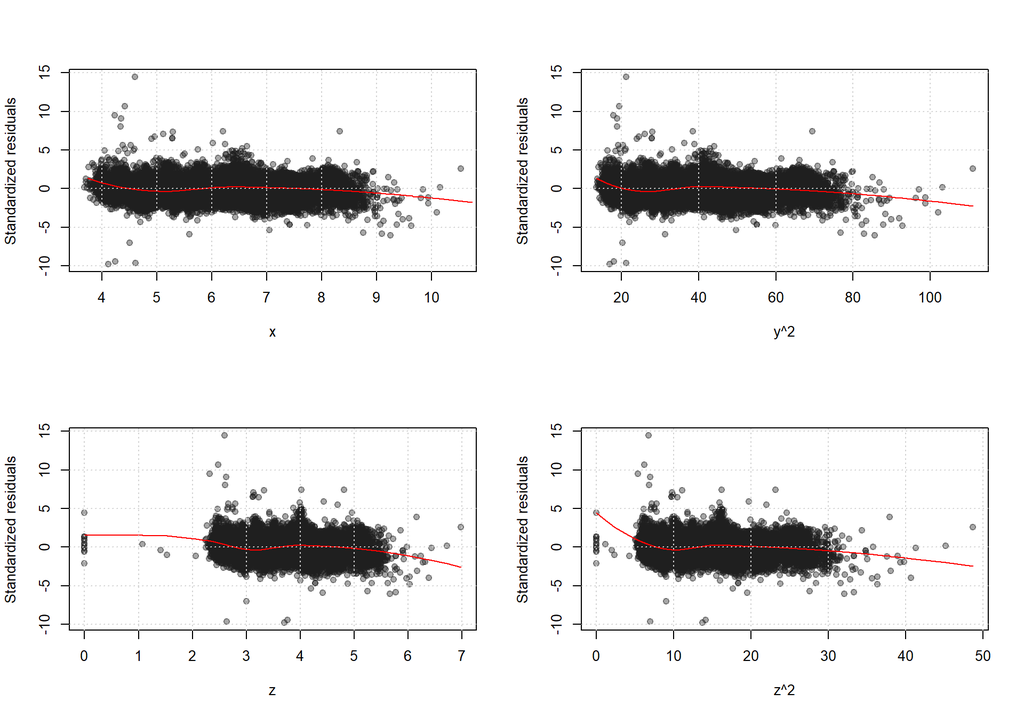

check for other interactions

```
## Single term additions
##
## Model:
## logprice ~ cut + color + clarity + depth + x + y + z + logcarat +
##     I(x^2) + I(y^2) + I(z^2)
##                  Df Sum of Sq    RSS     AIC   F value    Pr(>F)
## <none>                        815.41 -226004
## cut:color        24     4.688 810.73 -226267   12.9801 < 2.2e-16 ***
## cut:clarity      28     3.975 811.44 -226211    9.4257 < 2.2e-16 ***
## cut:depth         4     2.902 812.51 -226188   48.1298 < 2.2e-16 ***
## cut:x             4     3.108 812.31 -226202   51.5551 < 2.2e-16 ***
## cut:y             4     3.058 812.36 -226198   50.7203 < 2.2e-16 ***
## cut:z             4     3.161 812.25 -226205   52.4400 < 2.2e-16 ***
## cut:logcarat      4     3.224 812.19 -226209   53.4934 < 2.2e-16 ***
## cut:I(x^2)        4     2.473 812.94 -226160   40.9861 < 2.2e-16 ***
## cut:I(y^2)        4     2.460 812.95 -226159   40.7758 < 2.2e-16 ***
## cut:I(z^2)        4     2.470 812.94 -226159   40.9346 < 2.2e-16 ***
## color:clarity    42    76.795 738.62 -231254  133.3323 < 2.2e-16 ***
## color:depth       6     0.410 815.00 -226019    4.5153 0.0001395 ***
## color:x           6     2.337 813.08 -226147   25.8189 < 2.2e-16 ***
## color:y           6     2.410 813.00 -226151   26.6304 < 2.2e-16 ***
## color:z           6     2.224 813.19 -226139   24.5621 < 2.2e-16 ***
## color:logcarat    6     2.242 813.17 -226140   24.7721 < 2.2e-16 ***
## color:I(x^2)      6     2.712 812.70 -226171   29.9792 < 2.2e-16 ***
## color:I(y^2)      6     2.863 812.55 -226181   31.6535 < 2.2e-16 ***
## color:I(z^2)      6     2.587 812.83 -226163   28.5913 < 2.2e-16 ***
## clarity:depth     7     1.208 814.21 -226070   11.4218 1.446e-14 ***
## clarity:x         7     5.959 809.45 -226385   56.6833 < 2.2e-16 ***
## clarity:y         7     5.612 809.80 -226362   53.3605 < 2.2e-16 ***
## clarity:z         7     6.435 808.98 -226417   61.2492 < 2.2e-16 ***
## clarity:logcarat  7     6.332 809.08 -226410   60.2571 < 2.2e-16 ***
## clarity:I(x^2)    7     6.218 809.20 -226403   59.1655 < 2.2e-16 ***
## clarity:I(y^2)    7     5.894 809.52 -226381   56.0578 < 2.2e-16 ***
## clarity:I(z^2)    7     6.723 808.69 -226436   64.0133 < 2.2e-16 ***
## depth:x           1     0.414 815.00 -226029   27.3602 1.695e-07 ***
## depth:y           1     0.371 815.04 -226026   24.5679 7.196e-07 ***
## depth:z           1     1.747 813.67 -226117  115.7369 < 2.2e-16 ***
## depth:logcarat    1     0.996 814.42 -226068   65.9162 4.804e-16 ***
## depth:I(x^2)      1     0.534 814.88 -226037   35.3081 2.832e-09 ***
## depth:I(y^2)      1     0.488 814.92 -226034   32.3086 1.322e-08 ***
```

[output cut: 9 more lines]

```
## y:I(x^2)          1    25.149 790.26 -227691 1715.3502 < 2.2e-16 ***
## y:I(y^2)          1    35.464 779.95 -228400 2450.9315 < 2.2e-16 ***
## y:I(z^2)          1    22.854 792.56 -227535 1554.2768 < 2.2e-16 ***
## z:logcarat        1     0.181 815.23 -226014   11.9355 0.0005512 ***
## z:I(x^2)          1    15.577 799.84 -227042 1049.7282 < 2.2e-16 ***
## z:I(y^2)          1    18.225 797.19 -227221 1232.2652 < 2.2e-16 ***
## z:I(z^2)          1    25.298 790.11 -227701 1725.8648 < 2.2e-16 ***
## logcarat:I(x^2)   1    27.078 788.33 -227823 1851.4713 < 2.2e-16 ***
## logcarat:I(y^2)   1    30.740 784.67 -228074 2111.6620 < 2.2e-16 ***
## logcarat:I(z^2)   1    21.832 793.58 -227465 1482.8610 < 2.2e-16 ***
## I(x^2):I(y^2)     1    25.975 789.44 -227748 1773.5791 < 2.2e-16 ***
## I(x^2):I(z^2)     1    23.165 792.25 -227556 1576.0566 < 2.2e-16 ***
## I(y^2):I(z^2)     1    26.678 788.74 -227796 1823.1744 < 2.2e-16 ***
## ---
## Signif. codes:  0 '***' 0.001 '**' 0.01 '*' 0.05 '.' 0.1 ' ' 1
```

Im going to stick to the current predictors, since I dont like other interactions. Lets compare m2 and m3

```r
waldtest(m1, m2, vcov = vcovHC(m2, type = "HC0"))
```

```
## Wald test
##
## Model 1: logprice ~ cut + color + clarity + depth + table + x + y + z +
##     logcarat
## Model 2: logprice ~ cut + color + clarity + depth + table + x + y + z +
##     logcarat + I(x^2) + I(y^2) + I(z^2) + I(logcarat^2)
##   Res.Df Df      F    Pr(>F)
## 1  53905
## 2  53901  4 3959.9 < 2.2e-16 ***
## ---
## Signif. codes:  0 '***' 0.001 '**' 0.01 '*' 0.05 '.' 0.1 ' ' 1
```

```r
waldtest(m3, m2, vcov = vcovHC(m2, type = "HC0"))
```

```
## Wald test
##
## Model 1: logprice ~ cut + color + clarity + depth + x + y + z + logcarat +
##     I(x^2) + I(y^2) + I(z^2)
## Model 2: logprice ~ cut + color + clarity + depth + table + x + y + z +
##     logcarat + I(x^2) + I(y^2) + I(z^2) + I(logcarat^2)
##   Res.Df Df      F Pr(>F)
## 1  53903
## 2  53901  2 1.8481 0.1576
```

### Cook’s distance

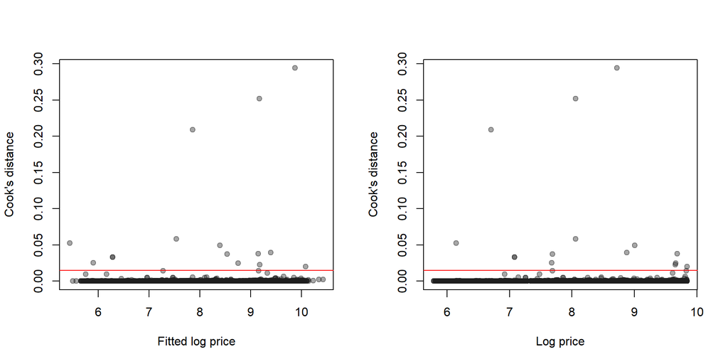

there are 25 observation higher than 0.005 cook’s distance. lets remove them all ### Model4 on excluded datapoints

Comparing how coefficients changed

```r
res <- cbind(coefficients(m3), coefficients(m4))
colnames(res) <- c("All data", "Filtered data")
res
```

```
##                 All data Filtered data
## (Intercept)   2.84700649    3.25757942
## cutGood       0.07427993    0.08279580
## cutIdeal      0.14719368    0.15720478
## cutPremium    0.12428306    0.12986962
## cutVery Good  0.10591623    0.11632519
## colorE       -0.05466099   -0.05437273
## colorF       -0.09407562   -0.09426199
## colorG       -0.16054603   -0.16095149
## colorH       -0.25185596   -0.25222061
## colorI       -0.37365080   -0.37387512
## colorJ       -0.51589738   -0.51578985
## clarityIF     1.10186174    1.10657759
## claritySI1    0.57902918    0.58065637
## claritySI2    0.41541519    0.41674077
## clarityVS1    0.79760294    0.80033132
## clarityVS2    0.72623009    0.72831980
## clarityVVS1   1.00472398    1.00799673
## clarityVVS2   0.93239740    0.93559544
## depth         0.01405783    0.01410579
## x             4.99728764    5.34983396
## y            -4.05852788   -4.52588868
## z             0.21460709    0.28541042
## logcarat      1.45494915    1.58514686
## I(x^2)       -0.38901748   -0.41296282
## I(y^2)        0.33848006    0.36870995
## I(z^2)       -0.03932301   -0.05376588
```

x,y,z changed significantly. we stay with model 4.

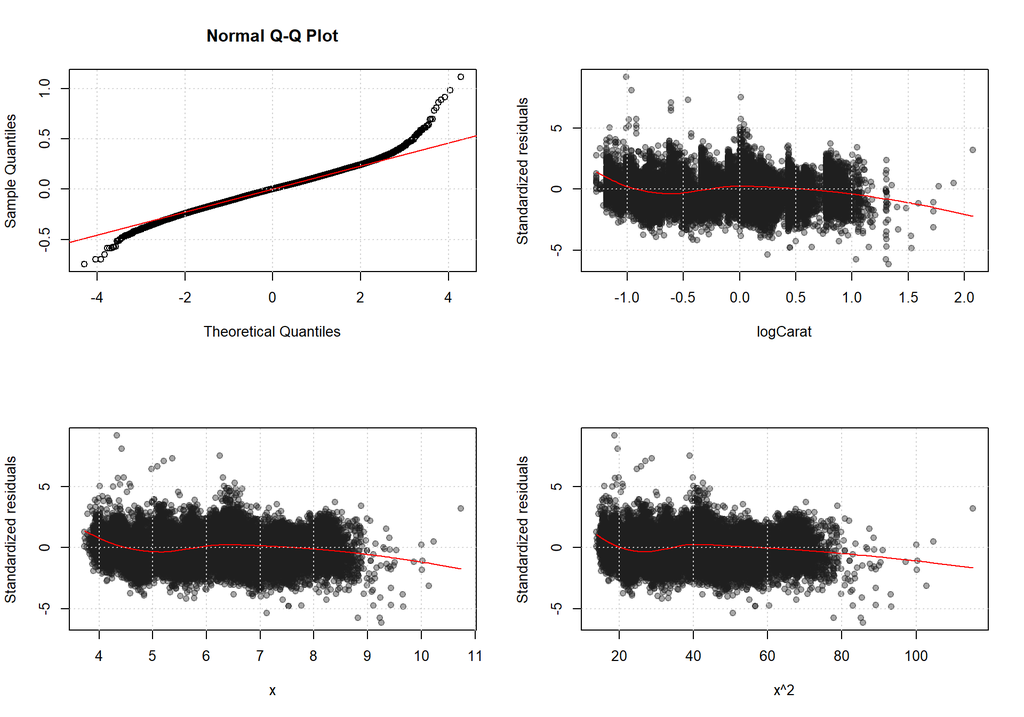

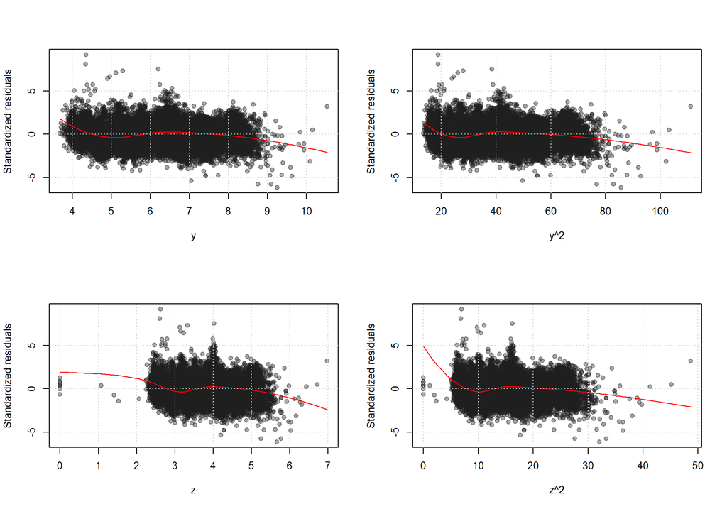

Everything looks better now. So final model for having carat as a continuous feature looks like following: ## Results The final model (#4) is build using 53904 of the initial 53,940 datapoints; it explains 98.5629631% of the variation in the logarithm of the price.

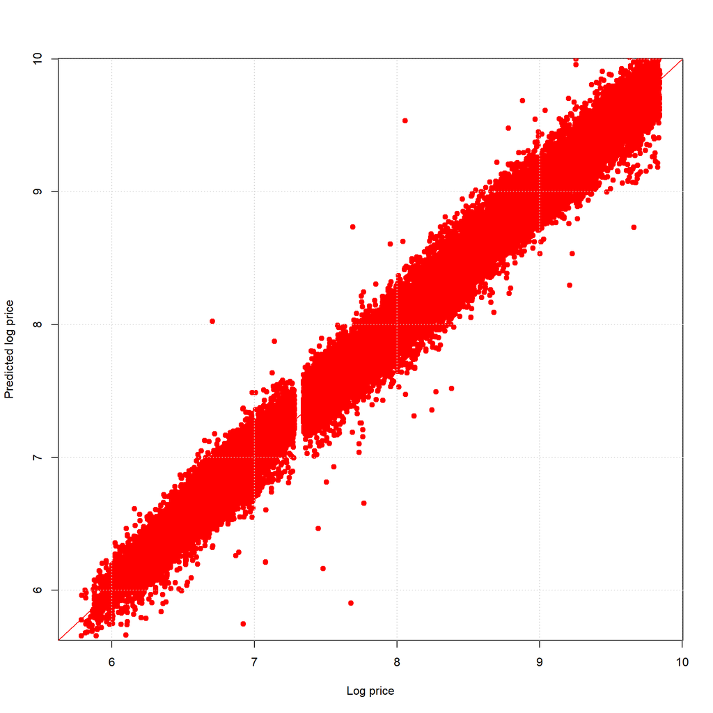

### Now working with carat as a categorical feature:

```r
data_2 <- data_cooks
data_2$size <- ifelse(exp(data_2$logcarat) < 0.3 , "small",
                    ifelse(exp(data_2$logcarat)> 1, "large", "medium"))
data_2$logcarat <- NULL
data_2
```

```
## # A tibble: 53,904 x 10
##    cut       color clarity depth table     x     y     z logprice size
##    <chr>     <chr> <chr>   <dbl> <dbl> <dbl> <dbl> <dbl>    <dbl> <chr>
##  1 Ideal     E     SI2      61.5    55  3.95  3.98  2.43     5.79 medium
##  2 Premium   E     SI1      59.8    61  3.89  3.84  2.31     5.79 small
##  3 Good      E     VS1      56.9    65  4.05  4.07  2.31     5.79 medium
##  4 Premium   I     VS2      62.4    58  4.2   4.23  2.63     5.81 medium
##  5 Good      J     SI2      63.3    58  4.34  4.35  2.75     5.81 medium
##  6 Very Good J     VVS2     62.8    57  3.94  3.96  2.48     5.82 medium
##  7 Very Good I     VVS1     62.3    57  3.95  3.98  2.47     5.82 medium
##  8 Very Good H     SI1      61.9    55  4.07  4.11  2.53     5.82 medium
##  9 Fair      E     VS2      65.1    61  3.87  3.78  2.49     5.82 small
## 10 Very Good H     VS1      59.4    61  4     4.05  2.39     5.82 medium
## # ... with 53,894 more rows
```

```r
data_2$price <- NULL
head(data_2)
```

```
## # A tibble: 6 x 10
##   cut       color clarity depth table     x     y     z logprice size
##   <chr>     <chr> <chr>   <dbl> <dbl> <dbl> <dbl> <dbl>    <dbl> <chr>
## 1 Ideal     E     SI2      61.5    55  3.95  3.98  2.43     5.79 medium
## 2 Premium   E     SI1      59.8    61  3.89  3.84  2.31     5.79 small
## 3 Good      E     VS1      56.9    65  4.05  4.07  2.31     5.79 medium
## 4 Premium   I     VS2      62.4    58  4.2   4.23  2.63     5.81 medium
## 5 Good      J     SI2      63.3    58  4.34  4.35  2.75     5.81 medium
## 6 Very Good J     VVS2     62.8    57  3.94  3.96  2.48     5.82 medium
```

### Model 5

For the sake of simplicity, I am going to use the same model for comparison, since the objective of study is to understand, whether having size feature changes results

Residuals visual inspection:

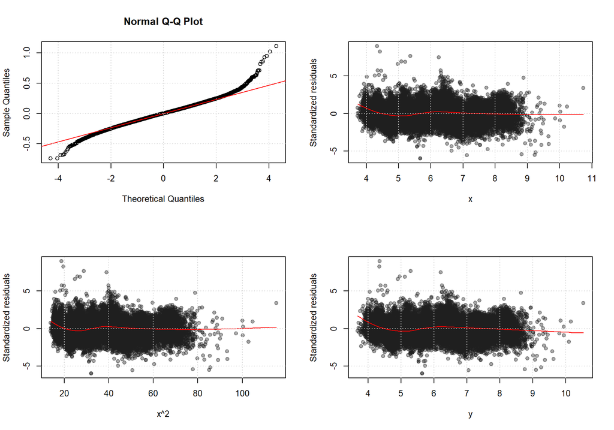

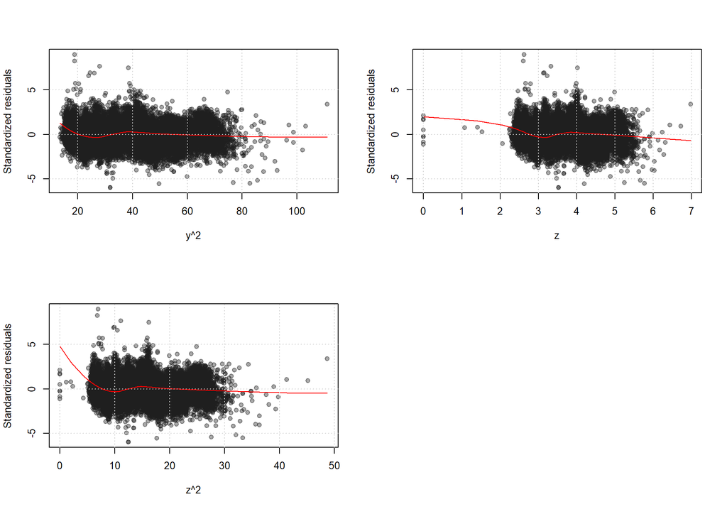

### Model 6 on subset chosen based on Cook’s distance

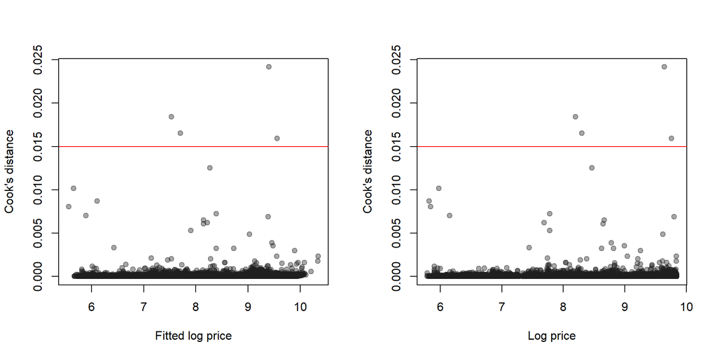

there are 15 observation higher than 0.005 cook’s distance. lets remove them all ### Model 6 on excluded datapoints

Comparing how coefficients changed

```r
res <- cbind(coefficients(m5), coefficients(m6))
colnames(res) <- c("All data", "Filtered data")
res
```

```
##                   All data Filtered data
## (Intercept)  -3.026879e+00  -3.074815424
## cutGood       7.474714e-02   0.075308064
## cutIdeal      1.253355e-01   0.126160533
## cutPremium    1.117656e-01   0.112865636
## cutVery Good  9.845522e-02   0.099285164
## colorE       -5.466328e-02  -0.054609388
## colorF       -9.500241e-02  -0.095046818
## colorG       -1.621091e-01  -0.162289283
## colorH       -2.533495e-01  -0.253452827
## colorI       -3.725661e-01  -0.372648594
## colorJ       -5.145298e-01  -0.514664138
## clarityIF     1.092569e+00   1.092863431
## claritySI1    5.753261e-01   0.575277633
## claritySI2    4.126261e-01   0.412535236
## clarityVS1    7.920144e-01   0.792089936
## clarityVS2    7.217077e-01   0.721752633
## clarityVVS1   9.984796e-01   0.998663288
## clarityVVS2   9.255534e-01   0.925683304
## depth         3.555427e-02   0.036250678
## x             5.876372e+00   5.882866012
## y            -4.064117e+00  -4.089791013
## z             3.856139e-02   0.072048233
## sizemedium   -4.685256e-02  -0.046921578
## sizesmall     1.860934e-02  -0.006524538
## I(x^2)       -4.270988e-01  -0.427527673
## I(y^2)        3.538957e-01   0.356227339
## I(z^2)        3.633492e-05  -0.005292756
```

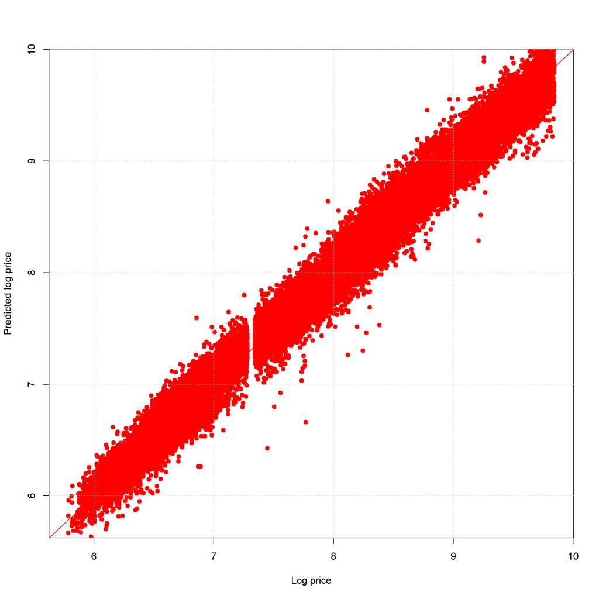

### Comparison of using carat as a size feature or as a continuous

```r
summary(m4)$r.squared - summary(m6)$r.squared
```

```
## [1] 0.000392542
```